# Analysis of longitudinal data

*This week we apply the methods learned so far to longitudinal data, i.e. data collected over a longer timeperiod, with several observations per subject.*

## Case 1: RATS!

### Overview

The data used in this exercise, based on data by Kimmo Vehkalahti found [here](https://raw.githubusercontent.com/KimmoVehkalahti/MABS/master/Examples/data/rats.txt), is from a nutrition study on three groups of rats, each rat’s weight being recorded approximately once a week for 9 weeks. That is, the data is longitudinal data tracking the individuals over a time period. The goal is to compare the trends of each group of rats. The data has been wrangled to a long (as opposed to wide) format.

Simply put, the variables are as follows:

```
##   ID Group  WD Weight Time
## 1  1     1 WD1    240    1
## 2  2     1 WD1    225    1
## 3  3     1 WD1    245    1
## 4  4     1 WD1    260    1
## 5  5     1 WD1    255    1
## 6  6     1 WD1    260    1
```

For a graphical overview, these are the trends over the 9-week time period across the three groups:

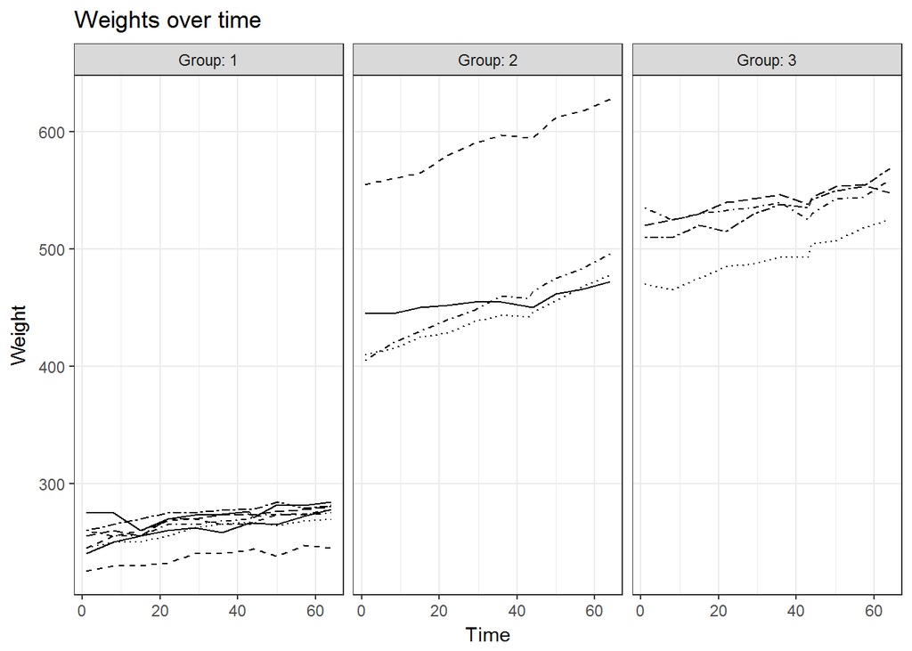

The rats in the first group weigh noticeably less than the other groups, whereas the rats in group 2 seem to at the end of the experiment weigh closer to what the rats in group 3 did at the beginning. Group 2 also includes what seems to be an outlier. With standardised weights, the data appears as follows, allowing for a closer tracking of individuals:

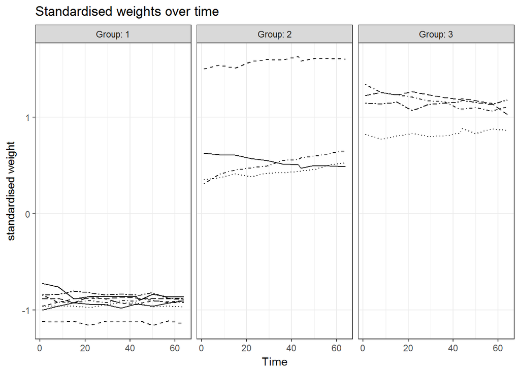

### Summary measure

To see the forest for the trees - or the groups for the individuals - it is helpful to plot the data in a way that shows the groups, not individuals.

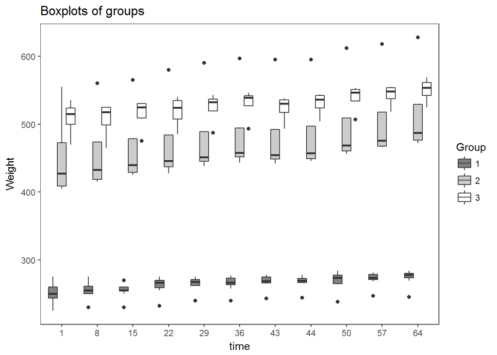

We shall now plot the summary measures, i.e. single values that represent all the observations of an individual. For this we use only the observations after the first measurement (Day 1).

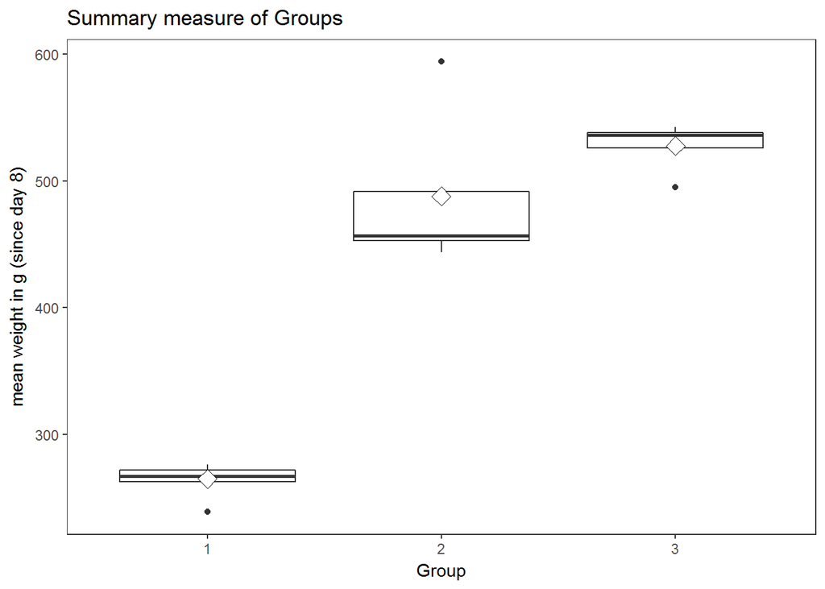

There are outliers in all Groups, so to remove bias we remove the outliers, i.e. the highest value from group 2 and the lowest values from Group 1 and Group 3. We repeat the plot without these outliers:

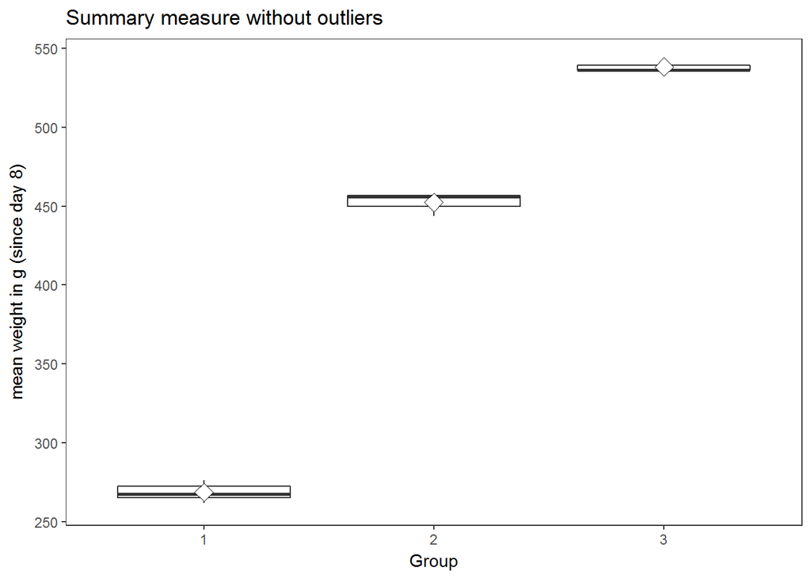

Now the groups appear more obviously different. Group 1 is noticeably lighter in weight than the two other groups, and the weights of the rats in Group 3 are very close to each other. We shall verify the difference of Group 2 and 3 using Student’s t-test.

```
##
##  Two Sample t-test
##
## data:  mean by Group
## t = -18.235, df = 4, p-value = 5.32e-05
## alternative hypothesis: true difference in means is not equal to 0
## 95 percent confidence interval:
##  -98.94088 -72.79246
## sample estimates:
## mean in group 2 mean in group 3
##        452.4000        538.2667
```

The p-value being 5.32e-05 confirms that these Groups indeed differ from each other in a statistically significant way.

## Case 2: A Brief Psychiatric Rating Scale (BPRS)

### Overview

BPRS is a measure on behaviour and psychiatric symptoms ([Wikipedia](https://en.wikipedia.org/wiki/Brief_Psychiatric_Rating_Scale)). In this dataset from [here](https://raw.githubusercontent.com/KimmoVehkalahti/MABS/master/Examples/data/BPRS.txt) male subjects from two treatment groups have been tested and rated on the BPRS in one initial test (no. 0) plus eight weeks. This too, is a longitudinal dataset that has been wrangled into long form. The data looks something like this:

```
##   treatment subject weeks bprs week
## 1         1       1 week0   42    0
## 2         1       2 week0   58    0
## 3         1       3 week0   54    0
## 4         1       4 week0   55    0
## 5         1       5 week0   72    0
## 6         1       6 week0   48    0
```

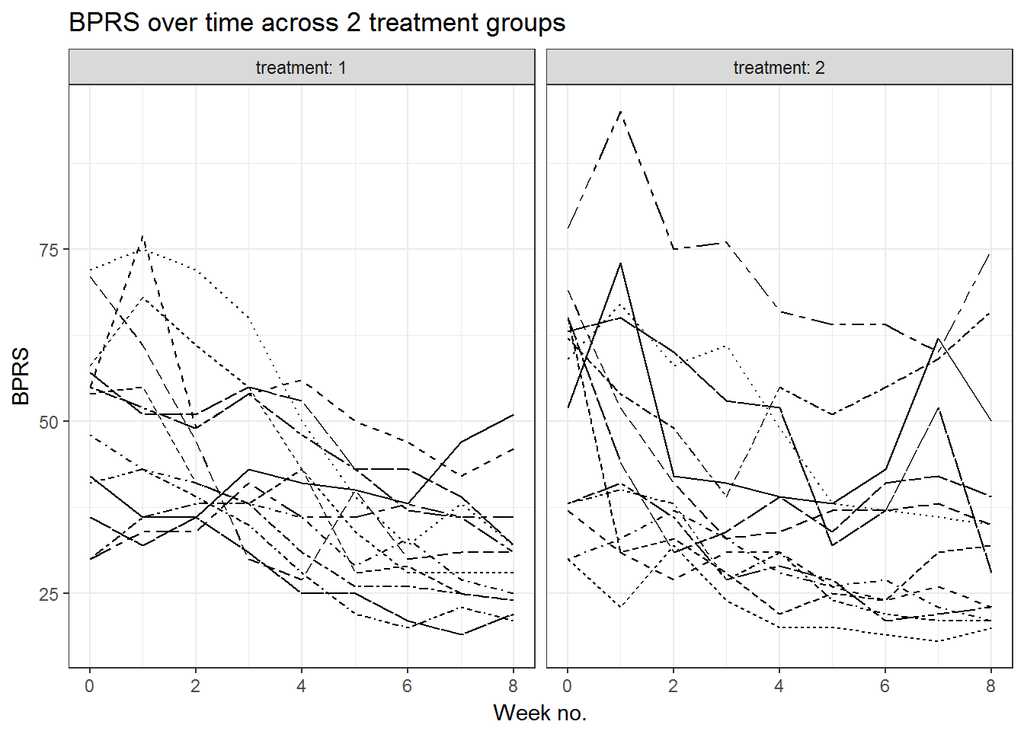

```r
ggplot(BPRS, aes(x=week, y=bprs, linetype=subject, fill = treatment)) +
  geom_line() +
  facet_grid(. ~ treatment, labeller = label_both) +
  scale_x_continuous(name = "Week no.") +
  scale_y_continuous(name = "BPRS")+
  ggtitle("BPRS over time across 2 treatment groups") +
  theme_bw() + theme(legend.position = "none")
```

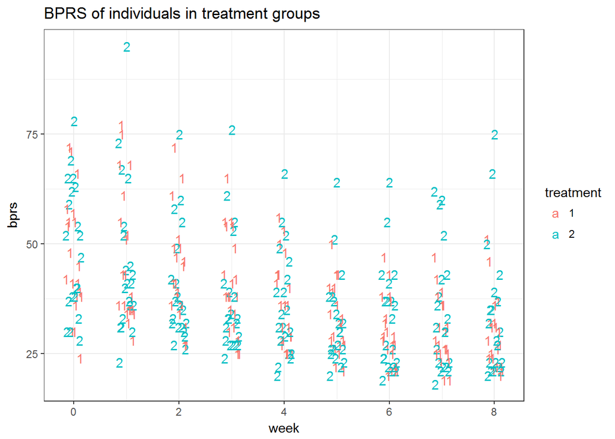

```r
ggplot(BPRS, aes(x = week, y = bprs, group = subject, color = treatment)) +
  geom_text(aes(label = treatment), position = position_dodge(width = 0.3)) +
  theme_bw() + ggtitle("BPRS of individuals in treatment groups")
```

In the first treatment group, the BPRS decreases over time for most individuals whereas in the second group the variation continues over the course of the testing.

### Linear models

We shall fit a linear regression model for the data using the variables *treatment* and *week* as explanatory variables, and *bprs* as the target variable.

```
##
## Call:
## lm(formula = bprs ~ week + treatment, data = BPRS)
##
## Residuals:
##     Min      1Q  Median      3Q     Max
## -22.454  -8.965  -3.196   7.002  50.244
##
## Coefficients:
##             Estimate Std. Error t value Pr(>|t|)
## (Intercept)  46.4539     1.3670  33.982   <2e-16 ***
## week         -2.2704     0.2524  -8.995   <2e-16 ***
## treatment2    0.5722     1.3034   0.439    0.661
## ---
## Signif. codes:  0 '***' 0.001 '**' 0.01 '*' 0.05 '.' 0.1 ' ' 1
##
## Residual standard error: 12.37 on 357 degrees of freedom
## Multiple R-squared:  0.1851, Adjusted R-squared:  0.1806
## F-statistic: 40.55 on 2 and 357 DF,  p-value: < 2.2e-16
```

Based on this model, the treatment is not a statistically significant variable. However, it should be noted that for longitudinal data, a linear model is quite naive - even false - because it does not track individuals over time, i.e. it treats observations over time as independent of each other - which does not correspond to the reality of the situation. Thus, using the same variables as above, we must also fit a *random intercepts model*, which does take in account the longitudinal aspect of the data and assumes heterogeneity in intercepts.

```
## Linear mixed model fit by maximum likelihood  ['lmerMod']
## Formula: bprs ~ week + treatment + (1 | subject)
##    Data: BPRS
##
##      AIC      BIC   logLik deviance df.resid
##   2748.7   2768.1  -1369.4   2738.7      355
##
## Scaled residuals:
##     Min      1Q  Median      3Q     Max
## -3.0481 -0.6749 -0.1361  0.4813  3.4855
##
## Random effects:
##  Groups   Name        Variance Std.Dev.
##  subject  (Intercept)  47.41    6.885
##  Residual             104.21   10.208
## Number of obs: 360, groups:  subject, 20
##
## Fixed effects:
##             Estimate Std. Error t value
## (Intercept)  46.4539     1.9090  24.334
## week         -2.2704     0.2084 -10.896
## treatment2    0.5722     1.0761   0.532
##
## Correlation of Fixed Effects:
##            (Intr) week
## week       -0.437
## treatment2 -0.282  0.000
```

Below is a random slope model for the data, which assumes heterogeneity in slopes. As well as an analysis of variance (ANOVA) test on the above *random intercept* and the below *random slope model*.

```
## Linear mixed model fit by maximum likelihood  ['lmerMod']
## Formula: bprs ~ week + treatment + (week | subject)
##    Data: BPRS
##
##      AIC      BIC   logLik deviance df.resid
##   2745.4   2772.6  -1365.7   2731.4      353
##
## Scaled residuals:
##     Min      1Q  Median      3Q     Max
## -2.8919 -0.6194 -0.0691  0.5531  3.7976
##
## Random effects:
##  Groups   Name        Variance Std.Dev. Corr
##  subject  (Intercept) 64.8202  8.0511
##           week         0.9608  0.9802   -0.51
##  Residual             97.4307  9.8707
## Number of obs: 360, groups:  subject, 20
##
## Fixed effects:
##             Estimate Std. Error t value
## (Intercept)  46.4539     2.1052  22.066
## week         -2.2704     0.2977  -7.626
## treatment2    0.5722     1.0405   0.550
##
## Correlation of Fixed Effects:
##            (Intr) week
## week       -0.582
## treatment2 -0.247  0.000
```

```
##
##
## ANOVA test
```

```
## Data: BPRS
## Models:
## BPRS_ref: bprs ~ week + treatment + (1 | subject)
## BPRS_ref1: bprs ~ week + treatment + (week | subject)
##           Df    AIC    BIC  logLik deviance  Chisq Chi Df Pr(>Chisq)
## BPRS_ref   5 2748.7 2768.1 -1369.4   2738.7
## BPRS_ref1  7 2745.4 2772.6 -1365.7   2731.4 7.2721      2    0.02636 *
## ---
## Signif. codes:  0 '***' 0.001 '**' 0.01 '*' 0.05 '.' 0.1 ' ' 1
```

The ANOVA results indicate a fairly good fit of the models (p<0.05), i.e. the models are statistically significantly different from each other. We shall thus fit a *random intercept and slope model*. Instead of being distinguised, we allow for week*treatment interaction. We conduct an ANOVA to compare this with the above models.

```
## Linear mixed model fit by maximum likelihood  ['lmerMod']
## Formula: bprs ~ week * treatment + (week | subject)
##    Data: BPRS
##
##      AIC      BIC   logLik deviance df.resid
##   2744.3   2775.4  -1364.1   2728.3      352
##
## Scaled residuals:
##     Min      1Q  Median      3Q     Max
## -3.0512 -0.6271 -0.0767  0.5288  3.9260
##
## Random effects:
##  Groups   Name        Variance Std.Dev. Corr
##  subject  (Intercept) 65.0016  8.0624
##           week         0.9688  0.9843   -0.51
##  Residual             96.4699  9.8219
## Number of obs: 360, groups:  subject, 20
##
## Fixed effects:
##                 Estimate Std. Error t value
## (Intercept)      47.8856     2.2522  21.262
## week             -2.6283     0.3589  -7.323
## treatment2       -2.2911     1.9090  -1.200
## week:treatment2   0.7158     0.4010   1.785
##
## Correlation of Fixed Effects:
##             (Intr) week   trtmn2
## week        -0.650
## treatment2  -0.424  0.469
## wek:trtmnt2  0.356 -0.559 -0.840
```

```
##
##
## ANOVA test with random intercept model
```

```
## Data: BPRS
## Models:
## BPRS_ref: bprs ~ week + treatment + (1 | subject)
## BPRS_ref2: bprs ~ week * treatment + (week | subject)
##           Df    AIC    BIC  logLik deviance  Chisq Chi Df Pr(>Chisq)
## BPRS_ref   5 2748.7 2768.1 -1369.4   2738.7
## BPRS_ref2  8 2744.3 2775.4 -1364.1   2728.3 10.443      3    0.01515 *
## ---
## Signif. codes:  0 '***' 0.001 '**' 0.01 '*' 0.05 '.' 0.1 ' ' 1
```

```
##
##
## ANOVA test with random slope model
```

```
## Data: BPRS
## Models:
## BPRS_ref1: bprs ~ week + treatment + (week | subject)
## BPRS_ref2: bprs ~ week * treatment + (week | subject)
##           Df    AIC    BIC  logLik deviance  Chisq Chi Df Pr(>Chisq)
## BPRS_ref1  7 2745.4 2772.6 -1365.7   2731.4
## BPRS_ref2  8 2744.3 2775.4 -1364.1   2728.3 3.1712      1    0.07495 .
## ---
## Signif. codes:  0 '***' 0.001 '**' 0.01 '*' 0.05 '.' 0.1 ' ' 1
```

Evidently the difference to the *random intercept model* is statistically significant, but the difference to the *random slope model* less so (yet still p<0.1).

Finally, we shall draw a plot that shows the fitted values of the *random intercept and slope model*.

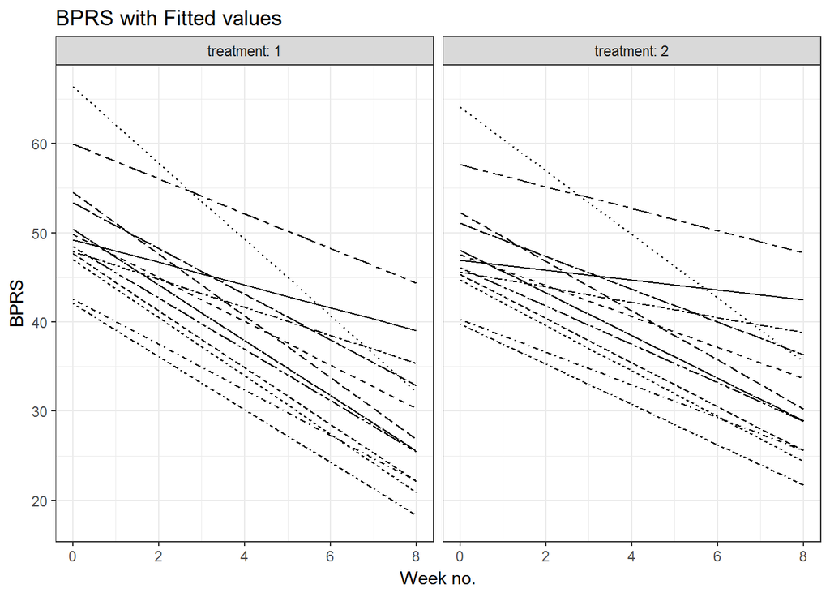

The difference is minimal even looking at the visualisation, and indeed [Vehkalahti & Everitt (2019: Chapter 8)](https://www.crcpress.com/Multivariate-Analysis-for-the-Behavioral-Sciences-Second-Edition/Vehkalahti-Everitt/p/book/9780815385158) confirm that the two treatment groups are not statistically significant.